# An Antarctic Tour of the Tidyverse

# purrr

I’m a big fan of the color palettes in the `nord` 📦

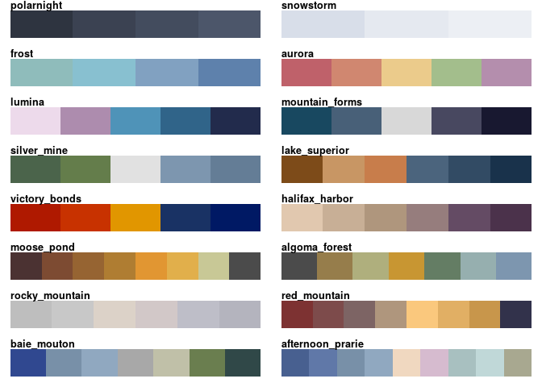

Ok now for a handy package/function trio!

`purrr`’s `map()` function can help us iterate the `prismatic::color()` function over all palettes in a palette package like `nord`!

```r
nord::nord_palettes %>% map(prismatic::color)
```

# Extra material below!

## Recreating a {palmerpenguins} plot

Let’s practice in real time!

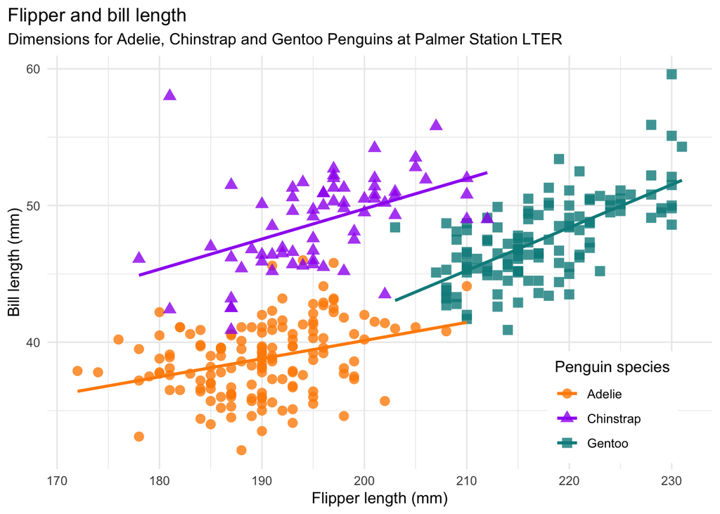

https://github.com/allisonhorst/palmerpenguins

# TidyTuesday

## Getting started

- [Intro Blog and history](https://themockup.blog/posts/2018-12-11-tidytuesday-a-weekly-social-data-project-in-r/)
- [Intro Tweet by Tom Mock (RStudio)](https://twitter.com/thomas_mock/status/1287774575833616384?s=20)
- [TidyTuesdays GitHub](https://github.com/rfordatascience/tidytuesday/blob/master/README.md)
- [TidyTuesday Podcast](https://twitter.com/tidypod)
- [TidyTuesday Sight-Unseen on YouTube](https://www.youtube.com/watch?v=ImpXawPNCfM)
- [{tidytuesdayR} package to help you easily download the data set](https://github.com/thebioengineer/tidytuesdayR)

## tidytuesdayR

```r
# install.packages("tidytuesdayR")
# remotes::install_github("thebioengineer/tidytuesdayR")

library(tidytuesdayR)

# load the data
tt_data <- tt_load("2020-07-27") # error message
tt_data <- tt_load("2020-07-28")
tt_data <- tt_load(2020, week=31)

# take a peek
readme(tt_data)
print(tt_data)
```

## Level up with modeling

- [Julia Silge (RStudio) teaches Tidymodels with {palmerpenguins} on YouTube](https://www.youtube.com/watch?v=z57i2GVcdww)

## Examples

- Specific to {palmerpenguins}:
  - Focus on fonts and formatting: https://twitter.com/ellamkaye/status/1289157139437621250?s=20
  - R-Ladies Ames: https://twitter.com/RLadiesAmes/status/1294425359388114944?s=20
- General to #tidytuesday:
  - R-Ladies Chicago TidyTuesday leader Ola!: https://twitter.com/AmazingSpeciali
  - R-Ladies Chicago TidyTuesday setup: https://twitter.com/RLadiesChicago/status/1192243170412761088?s=20